# Algoritmos de optimización - Reto 2

Nombre:  
Javier Martínez Arrieta Github:  
https://www.github.com/javierma/algoritmos_optimizacion

## Programación Dinámica. Viaje por el rio

- **Definición**: Es posible dividir el problema en subproblemas más pequeños, guardando las soluciones para ser utilizadas más adelante.
- **Características** que permiten identificar problemas aplicables:  
  -Es posible almacenar soluciones de los subproblemas para ser utilizados más adelante  
  -Debe verificar el principio de optimalidad de Bellman: “en una secuencia optima de decisiones, toda sub-secuencia también es óptima” (*)  
  -La necesidad de guardar la información acerca de las soluciones parciales unido a la recursividad provoca la necesidad de preocuparnos por la complejidad espacial (cuantos recursos de espacio usaremos)

### Problema

En un río hay **n** embarcaderos y debemos desplazarnos río abajo desde un embarcadero a otro. Cada embarcadero tiene precios diferentes para ir de un embarcadero a otro situado más abajo. Para ir del embarcadero i al j, puede ocurrir que sea más barato hacer un trasbordo por un embarcadero intermedio k. El problema consiste en determinar la combinación más barata.

- Resuelve el problema del descenso por el rio utilizando la técnica de optimización que consideres más adecuada.

```python
#Viaje por el rio - Programación dinámica
################################################################################

# Definimos un diccionario donde la clave será el origen y destino del tramo en forma de tupla y el valor el coste de ese camino o tramo
tramos_coste = {(0,1): 5, (0,2): 4, (0,3): 3, (1,3): 2, (1,4): 3, (1,6): 11, (2,3): 1, (2,5): 4, (2,6): 10, (3,4): 5, (3,5): 6, (3,6): 9, (4,6): 4, (5,6): 3}

# Definimos el origen y el destino
origen = 0
destino = 6

# Creamos dos listas, una con los tramos parciales y otra con el coste computado
tramos = []
costes_tramos = []

# Comenzamos los cálculos
i = 0
while i < destino:
    # Obtenemos los caminos desde el punto en que nos encontramos actualmente
    posibles_tramos = tramos_coste.keys()
    posibles_tramos = [tramo for tramo in posibles_tramos if tramo[0] == i]

    if i == origen:
        # Si se acaba de comenzar añadimos sin más los subtramos y el coste ya que la lista con los recorridos está vacía
        for tramo in posibles_tramos:
            tramos.append(str(tramo[0]) + '->' + str(tramo[1]))
            costes_tramos.append(tramos_coste[tramo])

    else:
        for tramo in posibles_tramos:
            j = 0
            while j < len(tramos):
                # Obtenemos los posibles destinos desde el punto en que nos encontramos
                fin_camino = int(tramos[j].split('->')[-1])

                # Comprobamos si el comienzo de tramo coincide con el final de los caminos ya calculados. De ser así, añadimos el camino hasta ahí y el coste
                if fin_camino == i:
                    tramos.append(tramos[j] + '->' + str(tramo[1]))
                    costes_tramos.append(costes_tramos[j] + tramos_coste[tramo])

                j = j + 1

    i = i + 1

# Recorremos la lista y buscamos el camino completo de menor coste. Si encontramos una ruta con menor coste que la guardado en mejor_ruto y coste_mejor_ruta o el coste de la mejor ruta es 0 actualizamos los valores
mejor_ruta = ''
coste_mejor_ruta = 0
i = 0
while i < len(tramos):
    if tramos[i].startswith(str(origen)) and tramos[i].endswith(str(destino)) and (coste_mejor_ruta == 0 or costes_tramos[i] < coste_mejor_ruta):
        mejor_ruta = tramos[i]
        coste_mejor_ruta = costes_tramos[i]

    i = i + 1

# Mostramos la rutaa de menor coste y el coste total
print('Ruta de menor coste:', mejor_ruta)
print('Coste total de la ruta:', coste_mejor_ruta)
```

```
Ruta de menor coste: 0->2->5->6
Coste total de la ruta: 11
```

## Descenso del gradiente

```python
import math                      #Funciones matematicas
import matplotlib.pyplot as plt  #Generacion de gráficos (otra opcion seaborn)
import numpy as np               #Tratamiento matriz N-dimensionales y otras (fundamental!)
#import scipy as sc

import random
```

Vamos a buscar el minimo de la funcion paraboloide : $$f(x) = x² + y²$$

```python
#Definimos la funcion
#Paraboloide
f  = lambda X:  X[0]**2 + X[1]**2    #Funcion
df = lambda X: [2*X[0] , 2*X[1]]         #Gradiente

df([1,2])
```

```
[2, 4]
```

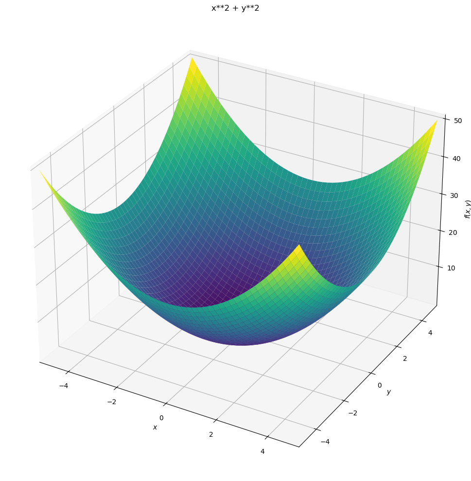

```
<sympy.plotting.plot.Plot at 0x147a86990>
```

```python
from sympy import symbols
from sympy.plotting import plot
from sympy.plotting import plot3d
x,y = symbols('x y')
plot3d(x**2 + y**2,
       (x,-5,5),(y,-5,5),
       title='x**2 + y**2',
       size=(10,10))
```

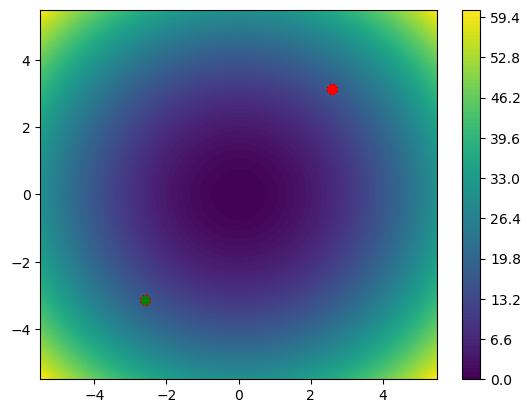

```
Solucion: [-2.5910488470033988, -3.1486946398967905] 16.627812062872422
```

```python
#Prepara los datos para dibujar mapa de niveles de Z
resolucion = 100
rango=5.5

X=np.linspace(-rango,rango,resolucion)
Y=np.linspace(-rango,rango,resolucion)
Z=np.zeros((resolucion,resolucion))
for ix,x in enumerate(X):
  for iy,y in enumerate(Y):
    Z[iy,ix] = f([x,y])

#Pinta el mapa de niveles de Z
plt.contourf(X,Y,Z,resolucion)
plt.colorbar()

#Generamos un punto aleatorio inicial y pintamos de blanco
P=[random.uniform(-5,5  ),random.uniform(-5,5 ) ]
plt.plot(P[0],P[1],"o",c="white")

#Tasa de aprendizaje. Fija. Sería más efectivo reducirlo a medida que nos acercamos.
TA=1

#Iteraciones:50
for _ in range(1000):
  grad = df(P)
  #print(P,grad)
  P[0],P[1] = P[0] - TA*grad[0] , P[1] - TA*grad[1]
  plt.plot(P[0],P[1],"o",c="red")

#Dibujamos el punto final y pintamos de verde
plt.plot(P[0],P[1],"o",c="green")
plt.show()
print("Solucion:" , P , f(P))
```